# Лабораторная работа №8

Операционные системы

Кузьмина М. К.

Российский университет дружбы народов, Москва, Россия

2025

# Задание

1. Записать в файл file.txt список файлов из /etc и домашнего каталога (~).
2. Вывести имена всех файлов из file.txt, имеющих расширение .conf, и записать их в conf.txt.
3. Найти файлы в домашнем каталоге, начинающиеся с c.
4. Вывести на экран (постранично) имена файлов из /etc, начинающиеся с h.
5. Запустить в фоновом режиме процесс, который записывает в ~/logfile файлы, начинающиеся с log.
6. Удалить ~/logfile.
7. Запустить редактор nano в фоновом режиме, определить PID процесса nano.
8. Завершить процесс nano с помощью kill.
9. Проверить использование диска (df) и размер каталогов (du).
10. Найти все директории в домашнем каталоге.

# Выполнение лабораторной работы

## Записать в файл file.txt список файлов из /etc и домашнего каталога (~).

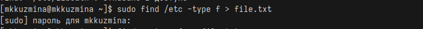

снимок экрана

снимок экрана

## Найти файлы в домашнем каталоге, начинающиеся с c.

Ищем файлы и каталоги, начинающиеся с c, в домашнем каталоге (рис.4):

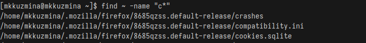

снимок экрана

## Вывести на экран (постранично) имена файлов из /etc, начинающиеся с h.

Ищем файлы в /etc, начинающиеся с h, и выводим их постранично (less) (рис.5:

снимок экрана

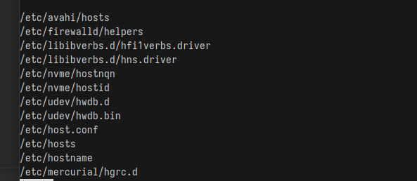

снимок экрана

## Запустить в фоновом режиме процесс, который записывает в ~/logfile файлы, начинающиеся с log.

Запускаем поиск файлов, начинающихся с log, и записываем их в ~/logfile. & – фоновый режим (рис.7):

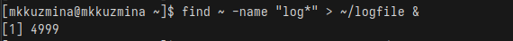

снимок экрана

## Удалить ~/logfile.

Удаляем файл ~/logfile (рис.8):

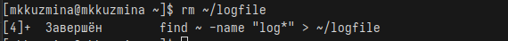

снимок экрана

## Запустить редактор nano в фоновом режиме, определить PID процесса nano.

Запускаем nano в фоновом режиме (рис.9):

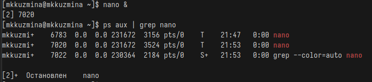

снимок экрана

## Проверить использование диска (df) и размер каталогов (du).

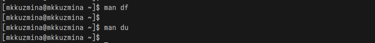

снимок экрана

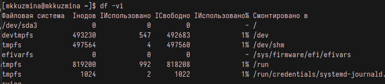

снимок экрана

снимок экрана

## Выводы

При выполнение лабораторной работы я ознакомилась с инструментами поиска файлов и фильтрации текстовых данных.Приобрела практические навыки: по управлению процессами (и заданиями), по проверке использования диска и обслуживанию файловых систем.